# Risk Factor Analysis

## Outcome Variable

**Outcome Variable:** ever_co

## Predictor Variables

**Intervention Variable:** cleanck

**Adjustment Set:**

- arm
- sex
- W_mage
- meducyrs
- feducyrs
- hhwealth_quart
- W_nrooms
- W_nhh
- W_nchldlt5
- trth2o
- impfloor
- delta_meducyrs
- delta_feducyrs
- delta_hhwealth_quart
- delta_W_nrooms
- delta_W_nhh
- delta_W_nchldlt5
- delta_trth2o
- delta_impfloor

## Stratifying Variables

The analysis was stratified on these variable(s):

- agecat
- studyid
- country

## Data Summary

| agecat | studyid | country | cleanck | ever_co | n_cell | n |
| --- | --- | --- | --- | --- | --- | --- |
| 0-24 months | CMC-V-BCS-2002 | INDIA | 1 | 0 | 142 | 373 |
| 0-24 months | CMC-V-BCS-2002 | INDIA | 1 | 1 | 21 | 373 |
| 0-24 months | CMC-V-BCS-2002 | INDIA | 0 | 0 | 145 | 373 |
| 0-24 months | CMC-V-BCS-2002 | INDIA | 0 | 1 | 65 | 373 |
| 0-24 months | GMS-Nepal | NEPAL | 1 | 0 | 10 | 612 |
| 0-24 months | GMS-Nepal | NEPAL | 1 | 1 | 0 | 612 |
| 0-24 months | GMS-Nepal | NEPAL | 0 | 0 | 421 | 612 |
| 0-24 months | GMS-Nepal | NEPAL | 0 | 1 | 181 | 612 |
| 0-24 months | IRC | INDIA | 1 | 0 | 198 | 400 |
| 0-24 months | IRC | INDIA | 1 | 1 | 33 | 400 |
| 0-24 months | IRC | INDIA | 0 | 0 | 130 | 400 |
| 0-24 months | IRC | INDIA | 0 | 1 | 39 | 400 |
| 0-24 months | MAL-ED | PERU | 1 | 0 | 1 | 2 |
| 0-24 months | MAL-ED | PERU | 1 | 1 | 0 | 2 |
| 0-24 months | MAL-ED | PERU | 0 | 0 | 1 | 2 |
| 0-24 months | MAL-ED | PERU | 0 | 1 | 0 | 2 |
| 0-24 months | MAL-ED | SOUTH AFRICA | 1 | 0 | 1 | 3 |
| 0-24 months | MAL-ED | SOUTH AFRICA | 1 | 1 | 1 | 3 |
| 0-24 months | MAL-ED | SOUTH AFRICA | 0 | 0 | 1 | 3 |
| 0-24 months | MAL-ED | SOUTH AFRICA | 0 | 1 | 0 | 3 |
| 0-24 months | NIH-Crypto | BANGLADESH | 1 | 0 | 329 | 577 |
| 0-24 months | NIH-Crypto | BANGLADESH | 1 | 1 | 31 | 577 |
| 0-24 months | NIH-Crypto | BANGLADESH | 0 | 0 | 200 | 577 |
| 0-24 months | NIH-Crypto | BANGLADESH | 0 | 1 | 17 | 577 |
| 0-24 months | PROVIDE | BANGLADESH | 1 | 0 | 508 | 700 |
| 0-24 months | PROVIDE | BANGLADESH | 1 | 1 | 63 | 700 |
| 0-24 months | PROVIDE | BANGLADESH | 0 | 0 | 102 | 700 |
| 0-24 months | PROVIDE | BANGLADESH | 0 | 1 | 27 | 700 |
| 0-6 months | CMC-V-BCS-2002 | INDIA | 1 | 0 | 156 | 368 |
| 0-6 months | CMC-V-BCS-2002 | INDIA | 1 | 1 | 6 | 368 |
| 0-6 months | CMC-V-BCS-2002 | INDIA | 0 | 0 | 181 | 368 |
| 0-6 months | CMC-V-BCS-2002 | INDIA | 0 | 1 | 25 | 368 |
| 0-6 months | GMS-Nepal | NEPAL | 1 | 0 | 10 | 612 |
| 0-6 months | GMS-Nepal | NEPAL | 1 | 1 | 0 | 612 |
| 0-6 months | GMS-Nepal | NEPAL | 0 | 0 | 572 | 612 |
| 0-6 months | GMS-Nepal | NEPAL | 0 | 1 | 30 | 612 |
| 0-6 months | IRC | INDIA | 1 | 0 | 219 | 399 |
| 0-6 months | IRC | INDIA | 1 | 1 | 12 | 399 |
| 0-6 months | IRC | INDIA | 0 | 0 | 156 | 399 |
| 0-6 months | IRC | INDIA | 0 | 1 | 12 | 399 |
| 0-6 months | MAL-ED | PERU | 1 | 0 | 1 | 2 |
| 0-6 months | MAL-ED | PERU | 1 | 1 | 0 | 2 |
| 0-6 months | MAL-ED | PERU | 0 | 0 | 1 | 2 |
| 0-6 months | MAL-ED | PERU | 0 | 1 | 0 | 2 |
| 0-6 months | MAL-ED | SOUTH AFRICA | 1 | 0 | 1 | 3 |
| 0-6 months | MAL-ED | SOUTH AFRICA | 1 | 1 | 1 | 3 |
| 0-6 months | MAL-ED | SOUTH AFRICA | 0 | 0 | 1 | 3 |
| 0-6 months | MAL-ED | SOUTH AFRICA | 0 | 1 | 0 | 3 |
| 0-6 months | NIH-Crypto | BANGLADESH | 1 | 0 | 355 | 577 |
| 0-6 months | NIH-Crypto | BANGLADESH | 1 | 1 | 5 | 577 |
| 0-6 months | NIH-Crypto | BANGLADESH | 0 | 0 | 210 | 577 |
| 0-6 months | NIH-Crypto | BANGLADESH | 0 | 1 | 7 | 577 |
| 0-6 months | PROVIDE | BANGLADESH | 1 | 0 | 549 | 700 |
| 0-6 months | PROVIDE | BANGLADESH | 1 | 1 | 22 | 700 |
| 0-6 months | PROVIDE | BANGLADESH | 0 | 0 | 121 | 700 |
| 0-6 months | PROVIDE | BANGLADESH | 0 | 1 | 8 | 700 |
| 6-24 months | CMC-V-BCS-2002 | INDIA | 1 | 0 | 147 | 373 |
| 6-24 months | CMC-V-BCS-2002 | INDIA | 1 | 1 | 16 | 373 |
| 6-24 months | CMC-V-BCS-2002 | INDIA | 0 | 0 | 156 | 373 |
| 6-24 months | CMC-V-BCS-2002 | INDIA | 0 | 1 | 54 | 373 |
| 6-24 months | GMS-Nepal | NEPAL | 1 | 0 | 8 | 529 |
| 6-24 months | GMS-Nepal | NEPAL | 1 | 1 | 0 | 529 |
| 6-24 months | GMS-Nepal | NEPAL | 0 | 0 | 348 | 529 |
| 6-24 months | GMS-Nepal | NEPAL | 0 | 1 | 173 | 529 |
| 6-24 months | IRC | INDIA | 1 | 0 | 202 | 400 |
| 6-24 months | IRC | INDIA | 1 | 1 | 29 | 400 |
| 6-24 months | IRC | INDIA | 0 | 0 | 137 | 400 |
| 6-24 months | IRC | INDIA | 0 | 1 | 32 | 400 |
| 6-24 months | MAL-ED | SOUTH AFRICA | 1 | 0 | 1 | 1 |
| 6-24 months | MAL-ED | SOUTH AFRICA | 1 | 1 | 0 | 1 |
| 6-24 months | MAL-ED | SOUTH AFRICA | 0 | 0 | 0 | 1 |
| 6-24 months | MAL-ED | SOUTH AFRICA | 0 | 1 | 0 | 1 |
| 6-24 months | NIH-Crypto | BANGLADESH | 1 | 0 | 316 | 559 |
| 6-24 months | NIH-Crypto | BANGLADESH | 1 | 1 | 27 | 559 |
| 6-24 months | NIH-Crypto | BANGLADESH | 0 | 0 | 200 | 559 |
| 6-24 months | NIH-Crypto | BANGLADESH | 0 | 1 | 16 | 559 |
| 6-24 months | PROVIDE | BANGLADESH | 1 | 0 | 456 | 614 |
| 6-24 months | PROVIDE | BANGLADESH | 1 | 1 | 51 | 614 |
| 6-24 months | PROVIDE | BANGLADESH | 0 | 0 | 83 | 614 |
| 6-24 months | PROVIDE | BANGLADESH | 0 | 1 | 24 | 614 |

The following strata were considered:

- agecat: 0-24 months, studyid: CMC-V-BCS-2002, country: INDIA
- agecat: 0-24 months, studyid: GMS-Nepal, country: NEPAL
- agecat: 0-24 months, studyid: IRC, country: INDIA
- agecat: 0-24 months, studyid: MAL-ED, country: PERU
- agecat: 0-24 months, studyid: MAL-ED, country: SOUTH AFRICA
- agecat: 0-24 months, studyid: NIH-Crypto, country: BANGLADESH
- agecat: 0-24 months, studyid: PROVIDE, country: BANGLADESH
- agecat: 0-6 months, studyid: CMC-V-BCS-2002, country: INDIA
- agecat: 0-6 months, studyid: GMS-Nepal, country: NEPAL
- agecat: 0-6 months, studyid: IRC, country: INDIA
- agecat: 0-6 months, studyid: MAL-ED, country: PERU
- agecat: 0-6 months, studyid: MAL-ED, country: SOUTH AFRICA
- agecat: 0-6 months, studyid: NIH-Crypto, country: BANGLADESH
- agecat: 0-6 months, studyid: PROVIDE, country: BANGLADESH
- agecat: 6-24 months, studyid: CMC-V-BCS-2002, country: INDIA
- agecat: 6-24 months, studyid: GMS-Nepal, country: NEPAL
- agecat: 6-24 months, studyid: IRC, country: INDIA
- agecat: 6-24 months, studyid: MAL-ED, country: SOUTH AFRICA
- agecat: 6-24 months, studyid: NIH-Crypto, country: BANGLADESH
- agecat: 6-24 months, studyid: PROVIDE, country: BANGLADESH

### Dropped Strata

Some strata were dropped due to rare outcomes:

- agecat: 0-24 months, studyid: GMS-Nepal, country: NEPAL
- agecat: 0-24 months, studyid: MAL-ED, country: PERU
- agecat: 0-24 months, studyid: MAL-ED, country: SOUTH AFRICA
- agecat: 0-6 months, studyid: GMS-Nepal, country: NEPAL
- agecat: 0-6 months, studyid: MAL-ED, country: PERU
- agecat: 0-6 months, studyid: MAL-ED, country: SOUTH AFRICA
- agecat: 6-24 months, studyid: GMS-Nepal, country: NEPAL
- agecat: 6-24 months, studyid: MAL-ED, country: SOUTH AFRICA

## Methods Detail

We’re interested in the causal parameters $E[Y_a]$ for all values of $a \in \mathcal{A}$. These parameters represent the mean outcome if, possibly contrary to fact, we intervened to set all units to have $A=a$. Under the randomization and positivity assumptions, these are identified by the statistical parameters $\psi_a=E_W[E_{Y|A,W}(Y|A=a,W)]$. In addition, we’re interested in the mean of $Y$, $E[Y]$ under no intervention (the observed mean). We will estimate these parameters by using SuperLearner to fit the relevant likelihood factors – $E_{Y|A,W}(Y|A=a,W)$ and $p(A=a|W)$, and then updating our likelihood fit using a joint TMLE.

For unadjusted analyses ($W=\{\}$), initial likelihoods were estimated using Lrnr_glm to estimate the simple $E(Y|A)$ and Lrnr_mean to estimate $p(A)$. For adjusted analyses, a small library containing Lrnr_glmnet, Lrnr_xgboost, and Lrnr_mean was used.

Having estimated these parameters, we will then use the delta method to estimate relative risks and attributable risks relative to a prespecified baseline level of $A$.

# Results Detail

## Results Plots

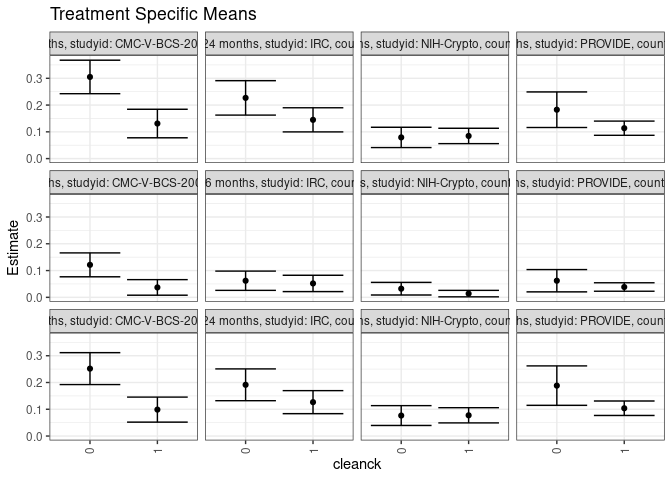

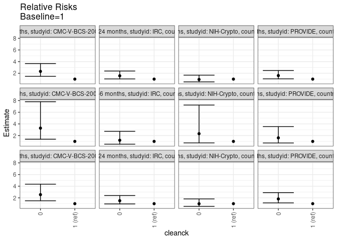

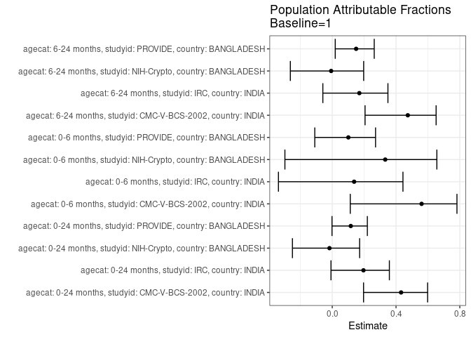

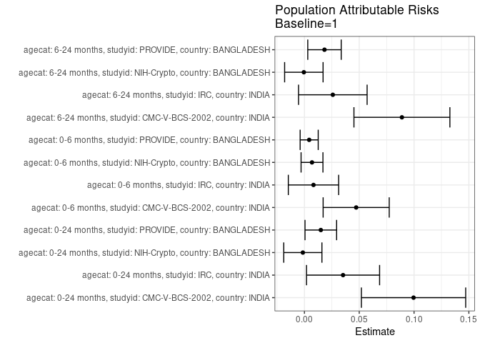

## Results Table

### Parameter: TSM

| agecat | studyid | country | intervention_level | baseline_level | estimate | ci_lower | ci_upper |
| --- | --- | --- | --- | --- | --- | --- | --- |
| 0-24 months | CMC-V-BCS-2002 | INDIA | 1 | NA | 0.1310409 | 0.0777548 | 0.1843269 |
| 0-24 months | CMC-V-BCS-2002 | INDIA | 0 | NA | 0.3050139 | 0.2424635 | 0.3675643 |
| 0-24 months | IRC | INDIA | 1 | NA | 0.1447710 | 0.0996804 | 0.1898617 |
| 0-24 months | IRC | INDIA | 0 | NA | 0.2268458 | 0.1625675 | 0.2911241 |
| 0-24 months | NIH-Crypto | BANGLADESH | 1 | NA | 0.0846371 | 0.0559104 | 0.1133638 |
| 0-24 months | NIH-Crypto | BANGLADESH | 0 | NA | 0.0791933 | 0.0413199 | 0.1170667 |
| 0-24 months | PROVIDE | BANGLADESH | 1 | NA | 0.1136270 | 0.0871274 | 0.1401265 |
| 0-24 months | PROVIDE | BANGLADESH | 0 | NA | 0.1826296 | 0.1161957 | 0.2490635 |
| 0-6 months | CMC-V-BCS-2002 | INDIA | 1 | NA | 0.0370370 | 0.0079162 | 0.0661579 |
| 0-6 months | CMC-V-BCS-2002 | INDIA | 0 | NA | 0.1213592 | 0.0767066 | 0.1660119 |
| 0-6 months | IRC | INDIA | 1 | NA | 0.0518970 | 0.0214138 | 0.0823802 |
| 0-6 months | IRC | INDIA | 0 | NA | 0.0619748 | 0.0259635 | 0.0979861 |
| 0-6 months | NIH-Crypto | BANGLADESH | 1 | NA | 0.0138889 | 0.0017893 | 0.0259885 |
| 0-6 months | NIH-Crypto | BANGLADESH | 0 | NA | 0.0322581 | 0.0087296 | 0.0557865 |
| 0-6 months | PROVIDE | BANGLADESH | 1 | NA | 0.0385289 | 0.0227309 | 0.0543269 |
| 0-6 months | PROVIDE | BANGLADESH | 0 | NA | 0.0620155 | 0.0203658 | 0.1036652 |
| 6-24 months | CMC-V-BCS-2002 | INDIA | 1 | NA | 0.0987439 | 0.0519469 | 0.1455408 |
| 6-24 months | CMC-V-BCS-2002 | INDIA | 0 | NA | 0.2518399 | 0.1922234 | 0.3114564 |
| 6-24 months | IRC | INDIA | 1 | NA | 0.1265979 | 0.0836389 | 0.1695568 |
| 6-24 months | IRC | INDIA | 0 | NA | 0.1913637 | 0.1319753 | 0.2507521 |
| 6-24 months | NIH-Crypto | BANGLADESH | 1 | NA | 0.0774560 | 0.0490708 | 0.1058412 |
| 6-24 months | NIH-Crypto | BANGLADESH | 0 | NA | 0.0765771 | 0.0395311 | 0.1136230 |
| 6-24 months | PROVIDE | BANGLADESH | 1 | NA | 0.1038552 | 0.0768337 | 0.1308768 |
| 6-24 months | PROVIDE | BANGLADESH | 0 | NA | 0.1883211 | 0.1147192 | 0.2619230 |

### Parameter: E(Y)

| agecat | studyid | country | intervention_level | baseline_level | estimate | ci_lower | ci_upper |
| --- | --- | --- | --- | --- | --- | --- | --- |
| 0-24 months | CMC-V-BCS-2002 | INDIA | NA | NA | 0.2305630 | 0.1877616 | 0.2733644 |
| 0-24 months | IRC | INDIA | NA | NA | 0.1800000 | 0.1423032 | 0.2176968 |
| 0-24 months | NIH-Crypto | BANGLADESH | NA | NA | 0.0831889 | 0.0606356 | 0.1057422 |
| 0-24 months | PROVIDE | BANGLADESH | NA | NA | 0.1285714 | 0.1037574 | 0.1533855 |
| 0-6 months | CMC-V-BCS-2002 | INDIA | NA | NA | 0.0842391 | 0.0558231 | 0.1126551 |
| 0-6 months | IRC | INDIA | NA | NA | 0.0601504 | 0.0367913 | 0.0835094 |
| 0-6 months | NIH-Crypto | BANGLADESH | NA | NA | 0.0207972 | 0.0091432 | 0.0324513 |
| 0-6 months | PROVIDE | BANGLADESH | NA | NA | 0.0428571 | 0.0278427 | 0.0578716 |
| 6-24 months | CMC-V-BCS-2002 | INDIA | NA | NA | 0.1876676 | 0.1479906 | 0.2273445 |
| 6-24 months | IRC | INDIA | NA | NA | 0.1525000 | 0.1172250 | 0.1877750 |
| 6-24 months | NIH-Crypto | BANGLADESH | NA | NA | 0.0769231 | 0.0548136 | 0.0990325 |
| 6-24 months | PROVIDE | BANGLADESH | NA | NA | 0.1221498 | 0.0962275 | 0.1480722 |

### Parameter: RR

| agecat | studyid | country | intervention_level | baseline_level | estimate | ci_lower | ci_upper |
| --- | --- | --- | --- | --- | --- | --- | --- |
| 0-24 months | CMC-V-BCS-2002 | INDIA | 1 | 1 | 1.0000000 | 1.0000000 | 1.000000 |
| 0-24 months | CMC-V-BCS-2002 | INDIA | 0 | 1 | 2.3276246 | 1.4777814 | 3.666196 |
| 0-24 months | IRC | INDIA | 1 | 1 | 1.0000000 | 1.0000000 | 1.000000 |
| 0-24 months | IRC | INDIA | 0 | 1 | 1.5669284 | 1.0287843 | 2.386569 |
| 0-24 months | NIH-Crypto | BANGLADESH | 1 | 1 | 1.0000000 | 1.0000000 | 1.000000 |
| 0-24 months | NIH-Crypto | BANGLADESH | 0 | 1 | 0.9356808 | 0.5204005 | 1.682355 |
| 0-24 months | PROVIDE | BANGLADESH | 1 | 1 | 1.0000000 | 1.0000000 | 1.000000 |
| 0-24 months | PROVIDE | BANGLADESH | 0 | 1 | 1.6072735 | 1.0444235 | 2.473449 |
| 0-6 months | CMC-V-BCS-2002 | INDIA | 1 | 1 | 1.0000000 | 1.0000000 | 1.000000 |
| 0-6 months | CMC-V-BCS-2002 | INDIA | 0 | 1 | 3.2766990 | 1.3753959 | 7.806302 |
| 0-6 months | IRC | INDIA | 1 | 1 | 1.0000000 | 1.0000000 | 1.000000 |
| 0-6 months | IRC | INDIA | 0 | 1 | 1.1941886 | 0.5223857 | 2.729949 |
| 0-6 months | NIH-Crypto | BANGLADESH | 1 | 1 | 1.0000000 | 1.0000000 | 1.000000 |
| 0-6 months | NIH-Crypto | BANGLADESH | 0 | 1 | 2.3225806 | 0.7456384 | 7.234581 |
| 0-6 months | PROVIDE | BANGLADESH | 1 | 1 | 1.0000000 | 1.0000000 | 1.000000 |
| 0-6 months | PROVIDE | BANGLADESH | 0 | 1 | 1.6095842 | 0.7327878 | 3.535487 |
| 6-24 months | CMC-V-BCS-2002 | INDIA | 1 | 1 | 1.0000000 | 1.0000000 | 1.000000 |
| 6-24 months | CMC-V-BCS-2002 | INDIA | 0 | 1 | 2.5504362 | 1.4978922 | 4.342586 |
| 6-24 months | IRC | INDIA | 1 | 1 | 1.0000000 | 1.0000000 | 1.000000 |
| 6-24 months | IRC | INDIA | 0 | 1 | 1.5115870 | 0.9537795 | 2.395622 |
| 6-24 months | NIH-Crypto | BANGLADESH | 1 | 1 | 1.0000000 | 1.0000000 | 1.000000 |
| 6-24 months | NIH-Crypto | BANGLADESH | 0 | 1 | 0.9886526 | 0.5392755 | 1.812494 |
| 6-24 months | PROVIDE | BANGLADESH | 1 | 1 | 1.0000000 | 1.0000000 | 1.000000 |
| 6-24 months | PROVIDE | BANGLADESH | 0 | 1 | 1.8133038 | 1.1354603 | 2.895804 |

### Parameter: PAR

| agecat | studyid | country | intervention_level | baseline_level | estimate | ci_lower | ci_upper |
| --- | --- | --- | --- | --- | --- | --- | --- |
| 0-24 months | CMC-V-BCS-2002 | INDIA | 1 | NA | 0.0995222 | 0.0519516 | 0.1470927 |
| 0-24 months | IRC | INDIA | 1 | NA | 0.0352290 | 0.0018960 | 0.0685620 |
| 0-24 months | NIH-Crypto | BANGLADESH | 1 | NA | -0.0014482 | -0.0188550 | 0.0159586 |
| 0-24 months | PROVIDE | BANGLADESH | 1 | NA | 0.0149444 | 0.0005273 | 0.0293615 |
| 0-6 months | CMC-V-BCS-2002 | INDIA | 1 | NA | 0.0472021 | 0.0170547 | 0.0773495 |
| 0-6 months | IRC | INDIA | 1 | NA | 0.0082534 | -0.0147011 | 0.0312079 |
| 0-6 months | NIH-Crypto | BANGLADESH | 1 | NA | 0.0069083 | -0.0030683 | 0.0168850 |
| 0-6 months | PROVIDE | BANGLADESH | 1 | NA | 0.0043282 | -0.0039085 | 0.0125650 |
| 6-24 months | CMC-V-BCS-2002 | INDIA | 1 | NA | 0.0889237 | 0.0451675 | 0.1326799 |
| 6-24 months | IRC | INDIA | 1 | NA | 0.0259021 | -0.0053697 | 0.0571740 |
| 6-24 months | NIH-Crypto | BANGLADESH | 1 | NA | -0.0005329 | -0.0180699 | 0.0170040 |
| 6-24 months | PROVIDE | BANGLADESH | 1 | NA | 0.0182946 | 0.0030466 | 0.0335426 |

### Parameter: PAF

| agecat | studyid | country | intervention_level | baseline_level | estimate | ci_lower | ci_upper |
| --- | --- | --- | --- | --- | --- | --- | --- |
| 0-24 months | CMC-V-BCS-2002 | INDIA | 1 | NA | 0.4316484 | 0.1962431 | 0.5981079 |
| 0-24 months | IRC | INDIA | 1 | NA | 0.1957166 | -0.0079513 | 0.3582311 |
| 0-24 months | NIH-Crypto | BANGLADESH | 1 | NA | -0.0174085 | -0.2496886 | 0.1716976 |
| 0-24 months | PROVIDE | BANGLADESH | 1 | NA | 0.1162346 | -0.0015395 | 0.2201593 |
| 0-6 months | CMC-V-BCS-2002 | INDIA | 1 | NA | 0.5603345 | 0.1129210 | 0.7820874 |
| 0-6 months | IRC | INDIA | 1 | NA | 0.1372127 | -0.3374455 | 0.4434151 |
| 0-6 months | NIH-Crypto | BANGLADESH | 1 | NA | 0.3321759 | -0.2968904 | 0.6561089 |
| 0-6 months | PROVIDE | BANGLADESH | 1 | NA | 0.1009924 | -0.1095560 | 0.2715873 |
| 6-24 months | CMC-V-BCS-2002 | INDIA | 1 | NA | 0.4738363 | 0.2058248 | 0.6514016 |
| 6-24 months | IRC | INDIA | 1 | NA | 0.1698501 | -0.0589667 | 0.3492253 |
| 6-24 months | NIH-Crypto | BANGLADESH | 1 | NA | -0.0069277 | -0.2627608 | 0.1970740 |
| 6-24 months | PROVIDE | BANGLADESH | 1 | NA | 0.1497719 | 0.0187782 | 0.2632779 |